# ANCOVA in TDE - Escrita (TDE - Escrita)

Geiser C. Challco geiser@alumni.usp.br

- Descriptive Statistics of Initial Data
- ANCOVA and Pairwise for one factor: **grupo**
  - Without remove non-normal data
  - Computing ANCOVA and PairWise After removing non-normal data (OK)
    - Plots for ancova
    - Checking linearity assumption
    - Checking normality and homogeneity
- ANCOVA and Pairwise for two factors **grupo:Sexo**
  - Without remove non-normal data
  - Computing ANCOVA and PairWise After removing non-normal data (OK)
    - Plots for ancova
    - Checking linearity assumption
    - Checking normality and homogeneity
- ANCOVA and Pairwise for two factors **grupo:Zona**
  - Without remove non-normal data
  - Computing ANCOVA and PairWise After removing non-normal data (OK)
    - Plots for ancova
    - Checking linearity assumption
    - Checking normality and homogeneity
- ANCOVA and Pairwise for two factors **grupo:Cor.Raca**
  - Without remove non-normal data
  - Computing ANCOVA and PairWise After removing non-normal data (OK)
    - Plots for ancova
    - Checking linearity assumption
    - Checking normality and homogeneity
- ANCOVA and Pairwise for two factors **grupo:Serie**
  - Without remove non-normal data
  - Computing ANCOVA and PairWise After removing non-normal data (OK)
    - Plots for ancova
    - Checking linearity assumption
    - Checking normality and homogeneity
- Summary of Results
  - Descriptive Statistics
  - ANCOVA Table Comparison
  - PairWise Table Comparison
  - EMMS Table Comparison

**NOTE**:

- Teste ANCOVA para determinar se houve diferenças significativas no TDE - Escrita (medido usando pre- e pos-testes).
- ANCOVA test to determine whether there were significant differences in TDE - Escrita (measured using pre- and post-tests).

# Descriptive Statistics of Initial Data

```r
df <- get.descriptives(dat, c(dv.pre, dv.pos), c("grupo"),
                       include.global = T, symmetry.test = T, normality.test = F)
df <- plyr::rbind.fill(
  df, do.call(plyr::rbind.fill, lapply(lfatores2, FUN = function(f) {
    if (nrow(dat) > 0 && sum(!is.na(unique(dat[[f]]))) > 1)
      get.descriptives(dat, c(dv.pre,dv.pos), c("grupo", f),
                       symmetry.test = T, normality.test = F)
    }))
)
(df <- df[,c(fatores1[fatores1 %in% colnames(df)],"variable",
             colnames(df)[!colnames(df) %in% c(fatores1,"variable")])])
```

```
##           grupo Sexo   Zona Cor.Raca Serie      variable   n   mean median min max     sd    se     ci
## 1      Controle <NA>   <NA>     <NA>  <NA> score.tde.pre  59 24.542   25.0  19  31  3.780 0.492  0.985
## 2  Experimental <NA>   <NA>     <NA>  <NA> score.tde.pre 117 25.855   26.0  19  31  3.422 0.316  0.627
## 3          <NA> <NA>   <NA>     <NA>  <NA> score.tde.pre 176 25.415   26.0  19  31  3.589 0.271  0.534
## 4      Controle <NA>   <NA>     <NA>  <NA> score.tde.pos  59 19.966   20.0   0  66 12.947 1.686  3.374
## 5  Experimental <NA>   <NA>     <NA>  <NA> score.tde.pos 117 24.675   25.0   0  60 12.203 1.128  2.234
## 6          <NA> <NA>   <NA>     <NA>  <NA> score.tde.pos 176 23.097   24.0   0  66 12.619 0.951  1.877
## 7      Controle    F   <NA>     <NA>  <NA> score.tde.pre  31 24.935   26.0  19  31  3.669 0.659  1.346
## 8      Controle    M   <NA>     <NA>  <NA> score.tde.pre  28 24.107   24.0  19  31  3.919 0.741  1.520
## 9  Experimental    F   <NA>     <NA>  <NA> score.tde.pre  49 26.184   26.0  19  31  3.073 0.439  0.883
## 10 Experimental    M   <NA>     <NA>  <NA> score.tde.pre  68 25.618   25.5  19  31  3.657 0.443  0.885
## 11     Controle    F   <NA>     <NA>  <NA> score.tde.pos  31 19.452   19.0   0  62 12.457 2.237  4.569
## 12     Controle    M   <NA>     <NA>  <NA> score.tde.pos  28 20.536   20.0   3  66 13.675 2.584  5.303
## 13 Experimental    F   <NA>     <NA>  <NA> score.tde.pos  49 24.510   25.0   2  60 12.045 1.721  3.460
## 14 Experimental    M   <NA>     <NA>  <NA> score.tde.pos  68 24.794   25.5   0  48 12.403 1.504  3.002
```

[output cut: 98 more lines]

| grupo | Sexo | Zona | Cor.Raca | Serie | variable | n | mean | median | min | max | sd | se | ci | iqr | symmetry | skewness | kurtosis |
| --- | --- | --- | --- | --- | --- | --- | --- | --- | --- | --- | --- | --- | --- | --- | --- | --- | --- |
| Controle |  |  |  |  | score.tde.pre | 59 | 24.542 | 25.0 | 19 | 31 | 3.780 | 0.492 | 0.985 | 6.00 | YES | -0.056 | -1.175 |
| Experimental |  |  |  |  | score.tde.pre | 117 | 25.855 | 26.0 | 19 | 31 | 3.422 | 0.316 | 0.627 | 6.00 | YES | -0.218 | -1.044 |
|  |  |  |  |  | score.tde.pre | 176 | 25.415 | 26.0 | 19 | 31 | 3.589 | 0.271 | 0.534 | 6.00 | YES | -0.197 | -1.029 |
| Controle |  |  |  |  | score.tde.pos | 59 | 19.966 | 20.0 | 0 | 66 | 12.947 | 1.686 | 3.374 | 13.50 | NO | 1.282 | 2.560 |
| Experimental |  |  |  |  | score.tde.pos | 117 | 24.675 | 25.0 | 0 | 60 | 12.203 | 1.128 | 2.234 | 16.00 | YES | 0.028 | -0.429 |
|  |  |  |  |  | score.tde.pos | 176 | 23.097 | 24.0 | 0 | 66 | 12.619 | 0.951 | 1.877 | 17.00 | YES | 0.450 | 0.295 |
| Controle | F |  |  |  | score.tde.pre | 31 | 24.935 | 26.0 | 19 | 31 | 3.669 | 0.659 | 1.346 | 5.50 | YES | -0.260 | -1.118 |
| Controle | M |  |  |  | score.tde.pre | 28 | 24.107 | 24.0 | 19 | 31 | 3.919 | 0.741 | 1.520 | 6.25 | YES | 0.168 | -1.232 |
| Experimental | F |  |  |  | score.tde.pre | 49 | 26.184 | 26.0 | 19 | 31 | 3.073 | 0.439 | 0.883 | 5.00 | YES | -0.355 | -0.718 |
| Experimental | M |  |  |  | score.tde.pre | 68 | 25.618 | 25.5 | 19 | 31 | 3.657 | 0.443 | 0.885 | 6.00 | YES | -0.098 | -1.259 |
| Controle | F |  |  |  | score.tde.pos | 31 | 19.452 | 19.0 | 0 | 62 | 12.457 | 2.237 | 4.569 | 14.00 | NO | 1.079 | 2.173 |
| Controle | M |  |  |  | score.tde.pos | 28 | 20.536 | 20.0 | 3 | 66 | 13.675 | 2.584 | 5.303 | 12.75 | NO | 1.369 | 2.358 |
| Experimental | F |  |  |  | score.tde.pos | 49 | 24.510 | 25.0 | 2 | 60 | 12.045 | 1.721 | 3.460 | 15.00 | YES | 0.260 | 0.197 |
| Experimental | M |  |  |  | score.tde.pos | 68 | 24.794 | 25.5 | 0 | 48 | 12.403 | 1.504 | 3.002 | 18.75 | YES | -0.127 | -0.892 |
| Controle |  | Rural |  |  | score.tde.pre | 21 | 23.429 | 25.0 | 19 | 31 | 3.429 | 0.748 | 1.561 | 7.00 | YES | 0.063 | -0.930 |
| Controle |  | Urbana |  |  | score.tde.pre | 20 | 25.150 | 26.0 | 19 | 31 | 3.787 | 0.847 | 1.773 | 5.50 | YES | -0.176 | -1.334 |
| Controle |  |  |  |  | score.tde.pre | 18 | 25.167 | 26.0 | 19 | 31 | 4.062 | 0.957 | 2.020 | 7.25 | YES | -0.213 | -1.487 |
| Experimental |  | Rural |  |  | score.tde.pre | 55 | 25.891 | 26.0 | 19 | 31 | 3.494 | 0.471 | 0.945 | 6.00 | YES | -0.258 | -1.149 |
| Experimental |  | Urbana |  |  | score.tde.pre | 27 | 25.778 | 26.0 | 19 | 31 | 3.389 | 0.652 | 1.341 | 5.00 | YES | -0.221 | -0.914 |
| Experimental |  |  |  |  | score.tde.pre | 35 | 25.857 | 26.0 | 19 | 31 | 3.431 | 0.580 | 1.179 | 6.00 | YES | -0.133 | -1.191 |
| Controle |  | Rural |  |  | score.tde.pos | 21 | 26.238 | 24.0 | 4 | 66 | 16.325 | 3.562 | 7.431 | 15.00 | NO | 0.871 | 0.301 |
| Controle |  | Urbana |  |  | score.tde.pos | 20 | 12.200 | 12.0 | 0 | 27 | 7.682 | 1.718 | 3.595 | 9.75 | YES | 0.280 | -0.890 |
| Controle |  |  |  |  | score.tde.pos | 18 | 21.278 | 22.0 | 6 | 45 | 8.428 | 1.987 | 4.191 | 8.25 | NO | 0.671 | 1.493 |
| Experimental |  | Rural |  |  | score.tde.pos | 55 | 25.873 | 26.0 | 1 | 48 | 11.898 | 1.604 | 3.216 | 18.00 | YES | -0.060 | -0.809 |
| Experimental |  | Urbana |  |  | score.tde.pos | 27 | 18.889 | 20.0 | 0 | 39 | 11.157 | 2.147 | 4.414 | 18.00 | YES | -0.145 | -1.321 |
| Experimental |  |  |  |  | score.tde.pos | 35 | 27.257 | 28.0 | 4 | 60 | 12.339 | 2.086 | 4.239 | 15.00 | YES | 0.154 | -0.049 |
| Controle |  |  | Branca |  | score.tde.pre | 3 | 23.333 | 23.0 | 19 | 28 | 4.509 | 2.603 | 11.202 | 4.50 | few data | 0.000 | 0.000 |
| Controle |  |  | Parda |  | score.tde.pre | 17 | 25.765 | 27.0 | 19 | 31 | 3.474 | 0.842 | 1.786 | 4.00 | NO | -0.656 | -0.691 |
| Controle |  |  |  |  | score.tde.pre | 39 | 24.103 | 25.0 | 19 | 31 | 3.831 | 0.613 | 1.242 | 6.00 | YES | 0.192 | -1.120 |
| Experimental |  |  | Amarela |  | score.tde.pre | 1 | 23.000 | 23.0 | 23 | 23 |  |  |  | 0.00 | few data | 0.000 | 0.000 |
| Experimental |  |  | Branca |  | score.tde.pre | 9 | 27.111 | 27.0 | 23 | 30 | 2.147 | 0.716 | 1.651 | 2.00 | YES | -0.464 | -0.906 |
| Experimental |  |  | Indígena |  | score.tde.pre | 3 | 24.000 | 25.0 | 21 | 26 | 2.646 | 1.528 | 6.572 | 2.50 | few data | 0.000 | 0.000 |
| Experimental |  |  | Parda |  | score.tde.pre | 46 | 25.239 | 25.0 | 19 | 31 | 3.465 | 0.511 | 1.029 | 5.00 | YES | 0.101 | -1.174 |
| Experimental |  |  |  |  | score.tde.pre | 58 | 26.293 | 27.0 | 19 | 31 | 3.519 | 0.462 | 0.925 | 5.00 | YES | -0.441 | -0.925 |
| Controle |  |  | Branca |  | score.tde.pos | 3 | 15.000 | 15.0 | 0 | 30 | 15.000 | 8.660 | 37.262 | 15.00 | few data | 0.000 | 0.000 |
| Controle |  |  | Parda |  | score.tde.pos | 17 | 17.706 | 19.0 | 3 | 45 | 10.833 | 2.627 | 5.570 | 17.00 | NO | 0.590 | -0.022 |
| Controle |  |  |  |  | score.tde.pos | 39 | 21.333 | 20.0 | 2 | 66 | 13.727 | 2.198 | 4.450 | 12.50 | NO | 1.407 | 2.452 |
| Experimental |  |  | Amarela |  | score.tde.pos | 1 | 23.000 | 23.0 | 23 | 23 |  |  |  | 0.00 | few data | 0.000 | 0.000 |
| Experimental |  |  | Branca |  | score.tde.pos | 9 | 20.222 | 21.0 | 1 | 39 | 11.987 | 3.996 | 9.214 | 5.00 | YES | -0.196 | -1.119 |
| Experimental |  |  | Indígena |  | score.tde.pos | 3 | 27.000 | 27.0 | 13 | 41 | 14.000 | 8.083 | 34.778 | 14.00 | few data | 0.000 | 0.000 |
| Experimental |  |  | Parda |  | score.tde.pos | 46 | 25.565 | 26.0 | 0 | 60 | 13.096 | 1.931 | 3.889 | 16.50 | YES | 0.063 | -0.298 |
| Experimental |  |  |  |  | score.tde.pos | 58 | 24.569 | 25.0 | 4 | 48 | 11.683 | 1.534 | 3.072 | 16.75 | YES | -0.024 | -0.853 |
| Controle |  |  |  | 6 ano | score.tde.pre | 17 | 24.235 | 25.0 | 19 | 31 | 3.993 | 0.968 | 2.053 | 7.00 | YES | 0.009 | -1.338 |
| Controle |  |  |  | 7 ano | score.tde.pre | 25 | 23.800 | 24.0 | 19 | 31 | 3.416 | 0.683 | 1.410 | 5.00 | YES | 0.158 | -1.112 |
| Controle |  |  |  | 8 ano | score.tde.pre | 10 | 26.500 | 27.0 | 19 | 31 | 4.143 | 1.310 | 2.964 | 3.50 | NO | -0.658 | -0.990 |
| Controle |  |  |  | 9 ano | score.tde.pre | 7 | 25.143 | 26.0 | 19 | 29 | 3.716 | 1.405 | 3.437 | 5.00 | YES | -0.397 | -1.518 |
| Experimental |  |  |  | 6 ano | score.tde.pre | 36 | 25.361 | 25.0 | 20 | 30 | 2.929 | 0.488 | 0.991 | 5.25 | YES | 0.117 | -1.257 |
| Experimental |  |  |  | 7 ano | score.tde.pre | 41 | 25.512 | 25.0 | 19 | 31 | 3.854 | 0.602 | 1.217 | 6.00 | YES | -0.219 | -1.228 |
| Experimental |  |  |  | 8 ano | score.tde.pre | 19 | 27.105 | 27.0 | 22 | 31 | 3.107 | 0.713 | 1.498 | 5.00 | YES | -0.282 | -1.474 |
| Experimental |  |  |  | 9 ano | score.tde.pre | 21 | 26.238 | 27.0 | 19 | 31 | 3.491 | 0.762 | 1.589 | 5.00 | YES | -0.404 | -1.031 |
| Controle |  |  |  | 6 ano | score.tde.pos | 17 | 16.529 | 14.0 | 4 | 36 | 10.180 | 2.469 | 5.234 | 13.00 | YES | 0.452 | -1.095 |
| Controle |  |  |  | 7 ano | score.tde.pos | 25 | 19.240 | 15.0 | 0 | 66 | 16.893 | 3.379 | 6.973 | 14.00 | NO | 1.422 | 1.387 |
| Controle |  |  |  | 8 ano | score.tde.pos | 10 | 22.800 | 25.0 | 15 | 27 | 4.417 | 1.397 | 3.160 | 5.50 | NO | -0.778 | -1.255 |
| Controle |  |  |  | 9 ano | score.tde.pos | 7 | 26.857 | 25.0 | 20 | 45 | 8.295 | 3.135 | 7.672 | 3.00 | NO | 1.378 | 0.355 |
| Experimental |  |  |  | 6 ano | score.tde.pos | 36 | 19.500 | 19.5 | 0 | 46 | 11.732 | 1.955 | 3.969 | 13.50 | YES | 0.352 | -0.501 |
| Experimental |  |  |  | 7 ano | score.tde.pos | 41 | 23.585 | 24.0 | 2 | 47 | 12.153 | 1.898 | 3.836 | 21.00 | YES | 0.043 | -1.126 |
| Experimental |  |  |  | 8 ano | score.tde.pos | 19 | 28.053 | 29.0 | 1 | 46 | 11.301 | 2.593 | 5.447 | 11.50 | YES | -0.498 | -0.229 |
| Experimental |  |  |  | 9 ano | score.tde.pos | 21 | 32.619 | 31.0 | 20 | 60 | 9.206 | 2.009 | 4.190 | 8.00 | NO | 1.233 | 1.532 |

# ANCOVA and Pairwise for one factor: **grupo**

## Without remove non-normal data

```r
pdat = remove_group_data(dat[!is.na(dat[["grupo"]]),], "score.tde.pos", "grupo")

pdat.long <- rbind(pdat[,c("id","grupo")], pdat[,c("id","grupo")])
pdat.long[["time"]] <- c(rep("pre", nrow(pdat)), rep("pos", nrow(pdat)))
pdat.long[["time"]] <- factor(pdat.long[["time"]], c("pre","pos"))
pdat.long[["score.tde"]] <- c(pdat[["score.tde.pre"]], pdat[["score.tde.pos"]])

aov = anova_test(pdat, score.tde.pos ~ score.tde.pre + grupo)
laov[["grupo"]] <- get_anova_table(aov)
```

```r
pwc <- emmeans_test(pdat, score.tde.pos ~ grupo, covariate = score.tde.pre,
                    p.adjust.method = "bonferroni")
```

```r
pwc.long <- emmeans_test(dplyr::group_by_at(pdat.long, "grupo"),
                          score.tde ~ time,
                          p.adjust.method = "bonferroni")
lpwc[["grupo"]] <- plyr::rbind.fill(pwc, pwc.long)
```

```r
ds <- get.descriptives(pdat, "score.tde.pos", "grupo", covar = "score.tde.pre")
ds <- merge(ds[ds$variable != "score.tde.pre",],
            ds[ds$variable == "score.tde.pre", !colnames(ds) %in% c("variable")],
            by = "grupo", all.x = T, suffixes = c("", ".score.tde.pre"))
ds <- merge(get_emmeans(pwc), ds, by = "grupo", suffixes = c(".emms", ""))
ds <- ds[,c("grupo","n","mean.score.tde.pre","se.score.tde.pre","mean","se","emmean","se.emms")]

colnames(ds) <- c("grupo", "N", paste0(c("M","SE")," (pre)"),
                  paste0(c("M","SE"), " (unadj)"), paste0(c("M", "SE"), " (adj)"))

lemms[["grupo"]] <- ds
```

## Computing ANCOVA and PairWise After removing non-normal data (OK)

```r
wdat = pdat

res = residuals(lm(score.tde.pos ~ score.tde.pre + grupo, data = wdat))
non.normal = getNonNormal(res, wdat$id, plimit = 0.05)

wdat = wdat[!wdat$id %in% non.normal,]

wdat.long <- rbind(wdat[,c("id","grupo")], wdat[,c("id","grupo")])
wdat.long[["time"]] <- c(rep("pre", nrow(wdat)), rep("pos", nrow(wdat)))
wdat.long[["time"]] <- factor(wdat.long[["time"]], c("pre","pos"))
wdat.long[["score.tde"]] <- c(wdat[["score.tde.pre"]], wdat[["score.tde.pos"]])

ldat[["grupo"]] = wdat

(non.normal)
```

```
## [1] "P962" "P984"
```

```r
aov = anova_test(wdat, score.tde.pos ~ score.tde.pre + grupo)
laov[["grupo"]] <- merge(get_anova_table(aov), laov[["grupo"]], by="Effect", suffixes = c("","'"))

(df = get_anova_table(aov))
```

```
## ANOVA Table (type II tests)
##
##          Effect DFn DFd      F        p p<.05   ges
## 1 score.tde.pre   1 171 11.710 0.000778     * 0.064
## 2         grupo   1 171  7.979 0.005000     * 0.045
```

| Effect | DFn | DFd | F | p | p<.05 | ges |
| --- | --- | --- | --- | --- | --- | --- |
| score.tde.pre | 1 | 171 | 11.710 | 0.001 | * | 0.064 |
| grupo | 1 | 171 | 7.979 | 0.005 | * | 0.045 |

| term | .y. | group1 | group2 | df | statistic | p | p.adj | p.adj.signif |
| --- | --- | --- | --- | --- | --- | --- | --- | --- |
| score.tde.pre*grupo | score.tde.pos | Controle | Experimental | 171 | -2.825 | 0.005 | 0.005 | ** |

```r
pwc.long <- emmeans_test(dplyr::group_by_at(wdat.long, "grupo"),
                         score.tde ~ time,
                         p.adjust.method = "bonferroni")
lpwc[["grupo"]] <- merge(plyr::rbind.fill(pwc, pwc.long), lpwc[["grupo"]], by=c("grupo","term",".y.","group1","group2"), suffixes = c("","'"))
```

| grupo | term | .y. | group1 | group2 | df | statistic | p | p.adj | p.adj.signif |
| --- | --- | --- | --- | --- | --- | --- | --- | --- | --- |
| Controle | time | score.tde | pre | pos | 344 | 3.834 | 0.000 | 0.000 | *** |
| Experimental | time | score.tde | pre | pos | 344 | 1.055 | 0.292 | 0.292 | ns |

```r
ds <- get.descriptives(wdat, "score.tde.pos", "grupo", covar = "score.tde.pre")
ds <- merge(ds[ds$variable != "score.tde.pre",],
            ds[ds$variable == "score.tde.pre", !colnames(ds) %in% c("variable")],
            by = "grupo", all.x = T, suffixes = c("", ".score.tde.pre"))
ds <- merge(get_emmeans(pwc), ds, by = "grupo", suffixes = c(".emms", ""))
ds <- ds[,c("grupo","n","mean.score.tde.pre","se.score.tde.pre","mean","se","emmean","se.emms")]

colnames(ds) <- c("grupo", "N", paste0(c("M","SE")," (pre)"),
                  paste0(c("M","SE"), " (unadj)"), paste0(c("M", "SE"), " (adj)"))

lemms[["grupo"]] <- merge(ds, lemms[["grupo"]], by=c("grupo"), suffixes = c("","'"))
```

| grupo | N | M (pre) | SE (pre) | M (unadj) | SE (unadj) | M (adj) | SE (adj) |
| --- | --- | --- | --- | --- | --- | --- | --- |
| Controle | 57 | 24.561 | 0.507 | 18.421 | 1.336 | 19.136 | 1.500 |
| Experimental | 117 | 25.855 | 0.316 | 24.675 | 1.128 | 24.327 | 1.042 |

### Plots for ancova

```r
plots <- oneWayAncovaPlots(
  wdat, "score.tde.pos", "grupo", aov, list("grupo"=pwc), addParam = c("mean_se"),
  font.label.size=10, step.increase=0.05, p.label="p.adj",
  subtitle = which(aov$Effect == "grupo"))
```

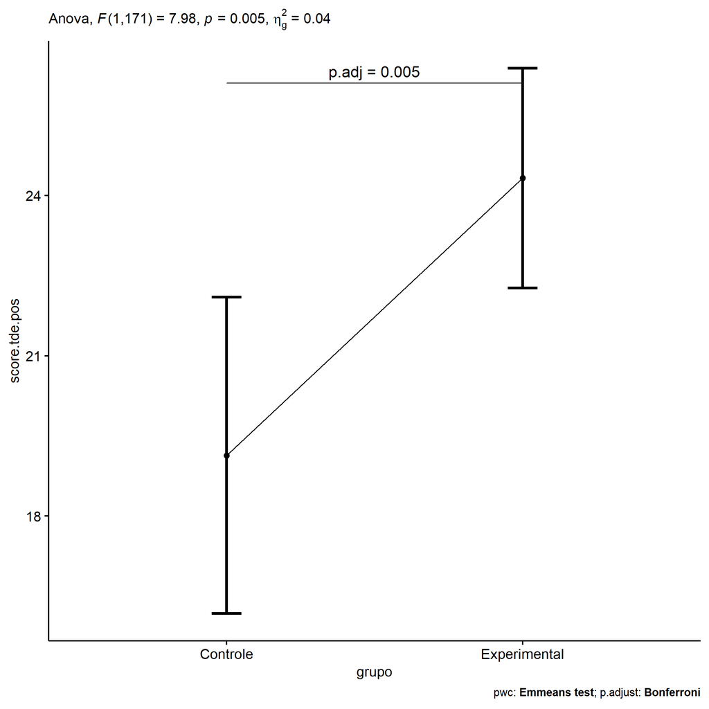

```r
if (!is.null(nrow(plots[["grupo"]]$data)))
  plots[["grupo"]] + ggplot2::scale_color_manual(values = color[["grupo"]])
```

```r
plots <- oneWayAncovaBoxPlots(
  wdat, "score.tde.pos", "grupo", aov, pwc, covar = "score.tde.pre",
  theme = "classic", color = color[["grupo"]],
  subtitle = which(aov$Effect == "grupo"))
```

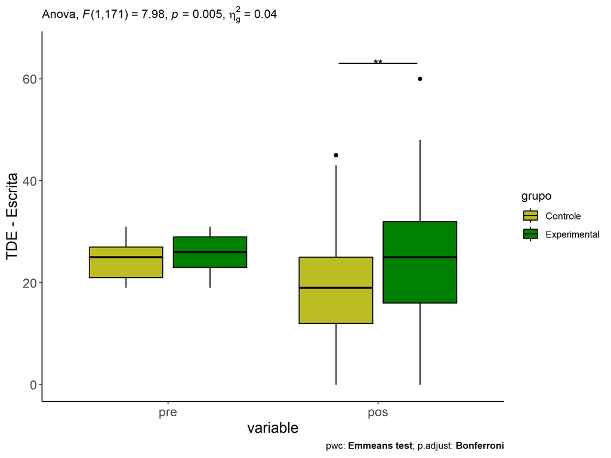

```r
if (length(unique(wdat[["grupo"]])) > 1)
  plots[["grupo"]] + ggplot2::ylab("TDE - Escrita") + ggplot2::scale_x_discrete(labels=c('pre', 'pos'))
```

```r
if (length(unique(wdat.long[["grupo"]])) > 1)
  plots <- oneWayAncovaBoxPlots(
    wdat.long, "score.tde", "grupo", aov, pwc.long, pre.post = "time",
    theme = "classic", color = color$prepost)
```

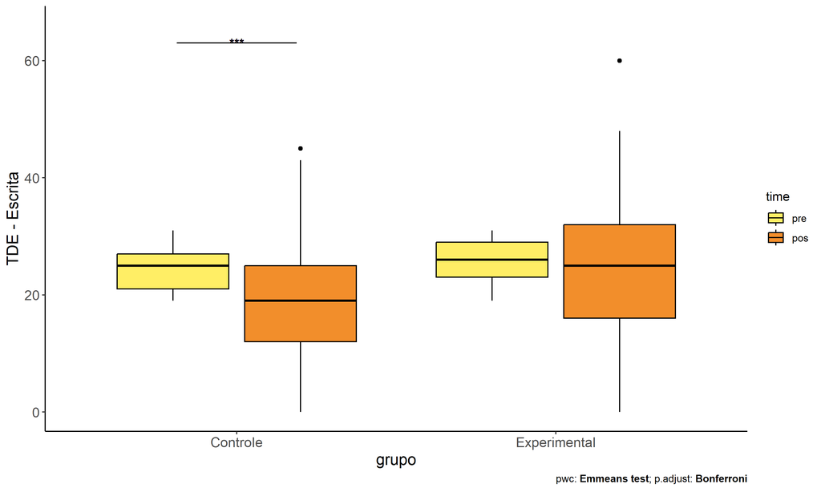

```r
if (length(unique(wdat.long[["grupo"]])) > 1)
  plots[["grupo"]] + ggplot2::ylab("TDE - Escrita")
```

### Checking linearity assumption

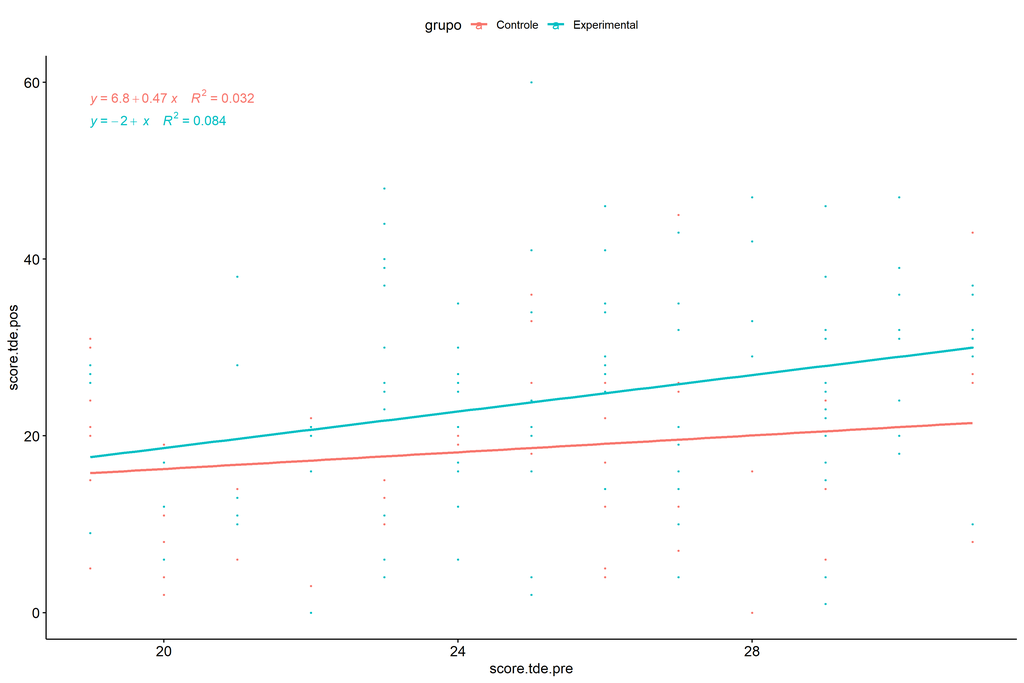

```r
ggscatter(wdat, x = "score.tde.pre", y = "score.tde.pos", size = 0.5,
          color = "grupo", add = "reg.line")+
  stat_regline_equation(
    aes(label =  paste(..eq.label.., ..rr.label.., sep = "~~~~"), color = grupo)
  )
```

### Checking normality and homogeneity

```r
res <- augment(lm(score.tde.pos ~ score.tde.pre + grupo, data = wdat))
```

```r
shapiro_test(res$.resid)
```

```
## # A tibble: 1 × 3
##   variable   statistic p.value
##   <chr>          <dbl>   <dbl>
## 1 res$.resid     0.993   0.526
```

```r
levene_test(res, .resid ~ grupo)
```

```
## # A tibble: 1 × 4
##     df1   df2 statistic     p
##   <int> <int>     <dbl> <dbl>
## 1     1   172      1.41 0.236
```

# ANCOVA and Pairwise for two factors **grupo:Sexo**

## Without remove non-normal data

```r
pdat = remove_group_data(dat[!is.na(dat[["grupo"]]) & !is.na(dat[["Sexo"]]),], "score.tde.pos", c("grupo","Sexo"))

pdat.long <- rbind(pdat[,c("id","grupo","Sexo")], pdat[,c("id","grupo","Sexo")])
pdat.long[["time"]] <- c(rep("pre", nrow(pdat)), rep("pos", nrow(pdat)))
pdat.long[["time"]] <- factor(pdat.long[["time"]], c("pre","pos"))
pdat.long[["score.tde"]] <- c(pdat[["score.tde.pre"]], pdat[["score.tde.pos"]])

aov = anova_test(pdat, score.tde.pos ~ score.tde.pre + grupo*Sexo)
laov[["grupo:Sexo"]] <- get_anova_table(aov)
```

```r
pwcs <- list()
pwcs[["Sexo"]] <- emmeans_test(
  group_by(pdat, grupo), score.tde.pos ~ Sexo,
  covariate = score.tde.pre, p.adjust.method = "bonferroni")
pwcs[["grupo"]] <- emmeans_test(
  group_by(pdat, Sexo), score.tde.pos ~ grupo,
  covariate = score.tde.pre, p.adjust.method = "bonferroni")

pwc <- plyr::rbind.fill(pwcs[["grupo"]], pwcs[["Sexo"]])
pwc <- pwc[,c("grupo","Sexo", colnames(pwc)[!colnames(pwc) %in% c("grupo","Sexo")])]
```

```r
pwc.long <- emmeans_test(dplyr::group_by_at(pdat.long, c("grupo","Sexo")),
                         score.tde ~ time,
                         p.adjust.method = "bonferroni")
lpwc[["grupo:Sexo"]] <- plyr::rbind.fill(pwc, pwc.long)
```

```r
ds <- get.descriptives(pdat, "score.tde.pos", c("grupo","Sexo"), covar = "score.tde.pre")
ds <- merge(ds[ds$variable != "score.tde.pre",],
            ds[ds$variable == "score.tde.pre", !colnames(ds) %in% c("variable")],
            by = c("grupo","Sexo"), all.x = T, suffixes = c("", ".score.tde.pre"))
ds <- merge(get_emmeans(pwcs[["grupo"]]), ds, by = c("grupo","Sexo"), suffixes = c(".emms", ""))
ds <- ds[,c("grupo","Sexo","n","mean.score.tde.pre","se.score.tde.pre","mean","se","emmean","se.emms")]

colnames(ds) <- c("grupo","Sexo", "N", paste0(c("M","SE")," (pre)"),
                  paste0(c("M","SE"), " (unadj)"), paste0(c("M", "SE"), " (adj)"))

lemms[["grupo:Sexo"]] <- ds
```

## Computing ANCOVA and PairWise After removing non-normal data (OK)

```r
wdat = pdat

res = residuals(lm(score.tde.pos ~ score.tde.pre + grupo*Sexo, data = wdat))
non.normal = getNonNormal(res, wdat$id, plimit = 0.05)

wdat = wdat[!wdat$id %in% non.normal,]

wdat.long <- rbind(wdat[,c("id","grupo","Sexo")], wdat[,c("id","grupo","Sexo")])
wdat.long[["time"]] <- c(rep("pre", nrow(wdat)), rep("pos", nrow(wdat)))
wdat.long[["time"]] <- factor(wdat.long[["time"]], c("pre","pos"))
wdat.long[["score.tde"]] <- c(wdat[["score.tde.pre"]], wdat[["score.tde.pos"]])


ldat[["grupo:Sexo"]] = wdat

(non.normal)
```

```
## [1] "P984" "P962"
```

```r
aov = anova_test(wdat, score.tde.pos ~ score.tde.pre + grupo*Sexo)
laov[["grupo:Sexo"]] <- merge(get_anova_table(aov), laov[["grupo:Sexo"]], by="Effect", suffixes = c("","'"))

(df = get_anova_table(aov))
```

```
## ANOVA Table (type II tests)
##
##          Effect DFn DFd      F        p p<.05      ges
## 1 score.tde.pre   1 169 11.940 0.000695     * 0.066000
## 2         grupo   1 169  7.405 0.007000     * 0.042000
## 3          Sexo   1 169  0.371 0.543000       0.002000
## 4    grupo:Sexo   1 169  0.060 0.807000       0.000354
```

| Effect | DFn | DFd | F | p | p<.05 | ges |
| --- | --- | --- | --- | --- | --- | --- |
| score.tde.pre | 1 | 169 | 11.940 | 0.001 | * | 0.066 |
| grupo | 1 | 169 | 7.405 | 0.007 | * | 0.042 |
| Sexo | 1 | 169 | 0.371 | 0.543 |  | 0.002 |
| grupo:Sexo | 1 | 169 | 0.060 | 0.807 |  | 0.000 |

```r
pwcs <- list()
pwcs[["Sexo"]] <- emmeans_test(
  group_by(wdat, grupo), score.tde.pos ~ Sexo,
  covariate = score.tde.pre, p.adjust.method = "bonferroni")
pwcs[["grupo"]] <- emmeans_test(
  group_by(wdat, Sexo), score.tde.pos ~ grupo,
  covariate = score.tde.pre, p.adjust.method = "bonferroni")

pwc <- plyr::rbind.fill(pwcs[["grupo"]], pwcs[["Sexo"]])
pwc <- pwc[,c("grupo","Sexo", colnames(pwc)[!colnames(pwc) %in% c("grupo","Sexo")])]
```

| grupo | Sexo | term | .y. | group1 | group2 | df | statistic | p | p.adj | p.adj.signif |
| --- | --- | --- | --- | --- | --- | --- | --- | --- | --- | --- |
|  | F | score.tde.pre*grupo | score.tde.pos | Controle | Experimental | 169 | -2.099 | 0.037 | 0.037 | * |
|  | M | score.tde.pre*grupo | score.tde.pos | Controle | Experimental | 169 | -1.782 | 0.077 | 0.077 | ns |
| Controle |  | score.tde.pre*Sexo | score.tde.pos | F | M | 169 | -0.552 | 0.582 | 0.582 | ns |
| Experimental |  | score.tde.pre*Sexo | score.tde.pos | F | M | 169 | -0.359 | 0.720 | 0.720 | ns |

```r
pwc.long <- emmeans_test(dplyr::group_by_at(wdat.long, c("grupo","Sexo")),
                         score.tde ~ time,
                         p.adjust.method = "bonferroni")
lpwc[["grupo:Sexo"]] <- merge(plyr::rbind.fill(pwc, pwc.long), lpwc[["grupo:Sexo"]], by=c("grupo","Sexo","term",".y.","group1","group2"), suffixes = c("","'"))
```

| grupo | Sexo | term | .y. | group1 | group2 | df | statistic | p | p.adj | p.adj.signif |
| --- | --- | --- | --- | --- | --- | --- | --- | --- | --- | --- |
| Controle | F | time | score.tde | pre | pos | 340 | 3.154 | 0.002 | 0.002 | ** |
| Controle | M | time | score.tde | pre | pos | 340 | 2.217 | 0.027 | 0.027 | * |
| Experimental | F | time | score.tde | pre | pos | 340 | 0.964 | 0.336 | 0.336 | ns |
| Experimental | M | time | score.tde | pre | pos | 340 | 0.559 | 0.577 | 0.577 | ns |

```r
ds <- get.descriptives(wdat, "score.tde.pos", c("grupo","Sexo"), covar = "score.tde.pre")
ds <- merge(ds[ds$variable != "score.tde.pre",],
            ds[ds$variable == "score.tde.pre", !colnames(ds) %in% c("variable")],
            by = c("grupo","Sexo"), all.x = T, suffixes = c("", ".score.tde.pre"))
ds <- merge(get_emmeans(pwcs[["grupo"]]), ds, by = c("grupo","Sexo"), suffixes = c(".emms", ""))
ds <- ds[,c("grupo","Sexo","n","mean.score.tde.pre","se.score.tde.pre","mean","se","emmean","se.emms")]

colnames(ds) <- c("grupo","Sexo", "N", paste0(c("M","SE")," (pre)"),
                  paste0(c("M","SE"), " (unadj)"), paste0(c("M", "SE"), " (adj)"))

lemms[["grupo:Sexo"]] <- merge(ds, lemms[["grupo:Sexo"]], by=c("grupo","Sexo"), suffixes = c("","'"))
```

| grupo | Sexo | N | M (pre) | SE (pre) | M (unadj) | SE (unadj) | M (adj) | SE (adj) |
| --- | --- | --- | --- | --- | --- | --- | --- | --- |
| Controle | F | 30 | 25.033 | 0.674 | 18.033 | 1.789 | 18.367 | 2.059 |
| Controle | M | 27 | 24.037 | 0.765 | 18.852 | 2.034 | 20.021 | 2.194 |
| Experimental | F | 49 | 26.184 | 0.439 | 24.510 | 1.721 | 23.879 | 1.620 |
| Experimental | M | 68 | 25.618 | 0.443 | 24.794 | 1.504 | 24.638 | 1.367 |

### Plots for ancova

```r
plots <- twoWayAncovaPlots(
  wdat, "score.tde.pos", c("grupo","Sexo"), aov, pwcs, addParam = c("mean_se"),
  font.label.size=10, step.increase=0.05, p.label="p.adj",
  subtitle = which(aov$Effect == "grupo:Sexo"))
```

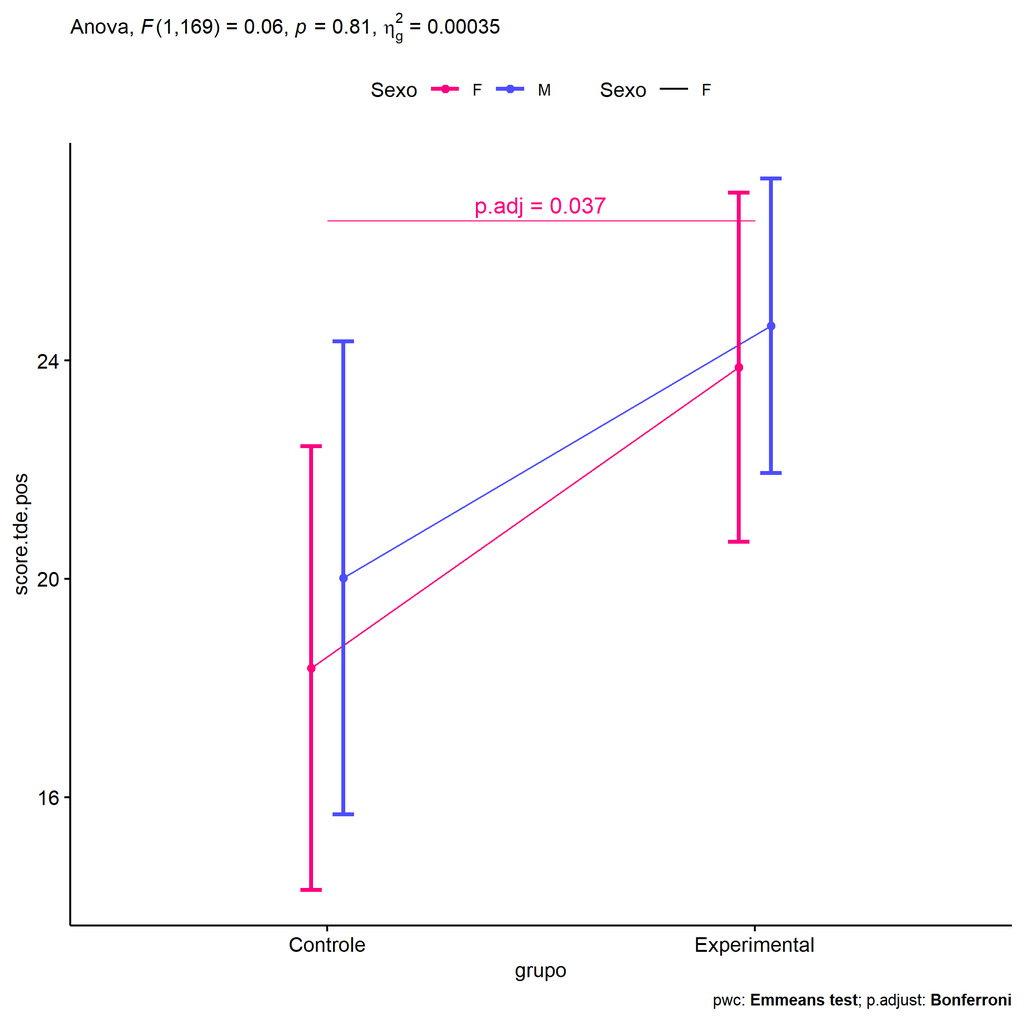

```r
if (!is.null(plots[["grupo"]]))
  plots[["grupo"]] + ggplot2::scale_color_manual(values = color[["Sexo"]])
```

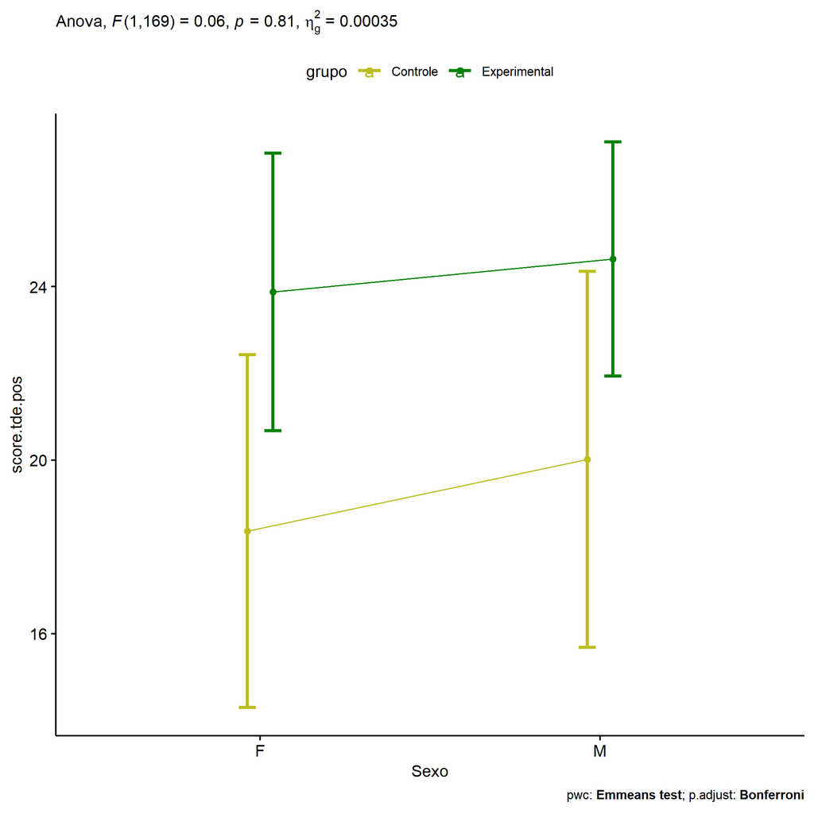

```r
if (!is.null(plots[["Sexo"]]))
  plots[["Sexo"]] + ggplot2::scale_color_manual(values = color[["grupo"]])
```

```r
plots <- twoWayAncovaBoxPlots(
  wdat, "score.tde.pos", c("grupo","Sexo"), aov, pwcs, covar = "score.tde.pre",
  theme = "classic", color = color[["grupo:Sexo"]],
  subtitle = which(aov$Effect == "grupo:Sexo"))
```

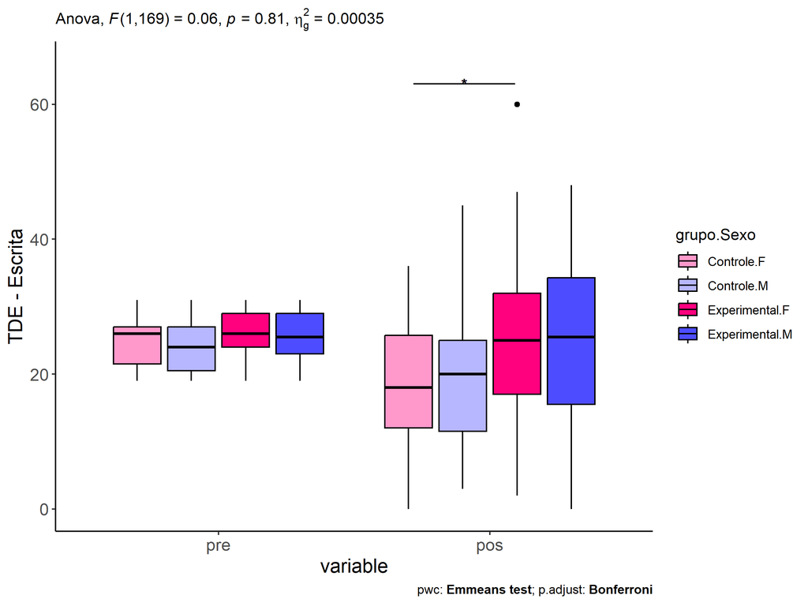

```r
plots[["grupo:Sexo"]] + ggplot2::ylab("TDE - Escrita") + ggplot2::scale_x_discrete(labels=c('pre', 'pos'))
```

```r
plots <- twoWayAncovaBoxPlots(
  wdat.long, "score.tde", c("grupo","Sexo"), aov, pwc.long, pre.post = "time",
  theme = "classic", color = color$prepost)
```

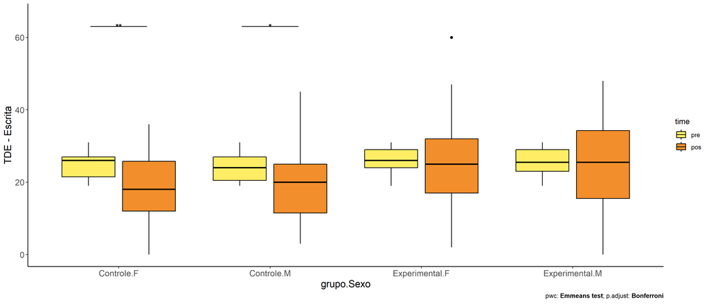

```r
plots[["grupo:Sexo"]] + ggplot2::ylab("TDE - Escrita")
```

### Checking linearity assumption

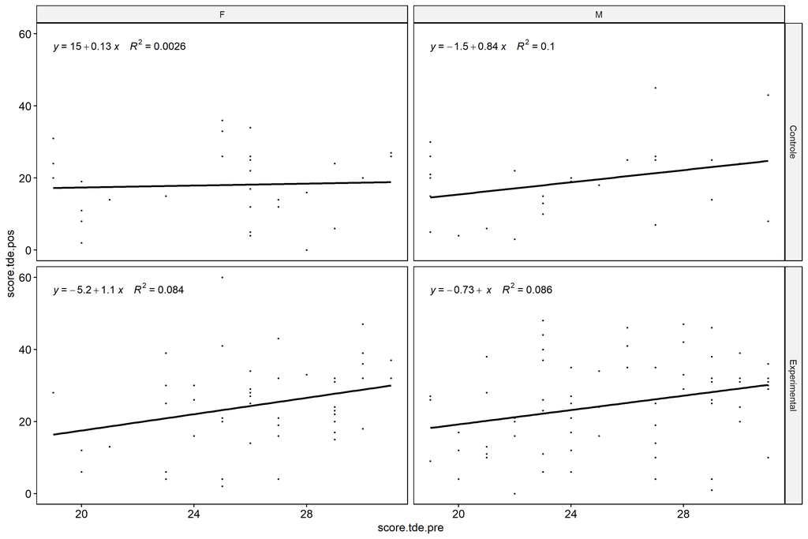

```r
ggscatter(wdat, x = "score.tde.pre", y = "score.tde.pos", size = 0.5,
          facet.by = c("grupo","Sexo"), add = "reg.line")+
  stat_regline_equation(
    aes(label =  paste(..eq.label.., ..rr.label.., sep = "~~~~"))
  )
```

### Checking normality and homogeneity

```r
res <- augment(lm(score.tde.pos ~ score.tde.pre + grupo*Sexo, data = wdat))
```

```r
shapiro_test(res$.resid)
```

```
## # A tibble: 1 × 3
##   variable   statistic p.value
##   <chr>          <dbl>   <dbl>
## 1 res$.resid     0.993   0.610
```

```r
levene_test(res, .resid ~ grupo*Sexo)
```

```
## # A tibble: 1 × 4
##     df1   df2 statistic     p
##   <int> <int>     <dbl> <dbl>
## 1     3   170     0.537 0.657
```

# ANCOVA and Pairwise for two factors **grupo:Zona**

## Without remove non-normal data

```r
pdat = remove_group_data(dat[!is.na(dat[["grupo"]]) & !is.na(dat[["Zona"]]),], "score.tde.pos", c("grupo","Zona"))

pdat.long <- rbind(pdat[,c("id","grupo","Zona")], pdat[,c("id","grupo","Zona")])
pdat.long[["time"]] <- c(rep("pre", nrow(pdat)), rep("pos", nrow(pdat)))
pdat.long[["time"]] <- factor(pdat.long[["time"]], c("pre","pos"))
pdat.long[["score.tde"]] <- c(pdat[["score.tde.pre"]], pdat[["score.tde.pos"]])

aov = anova_test(pdat, score.tde.pos ~ score.tde.pre + grupo*Zona)
laov[["grupo:Zona"]] <- get_anova_table(aov)
```

```r
pwcs <- list()
pwcs[["Zona"]] <- emmeans_test(
  group_by(pdat, grupo), score.tde.pos ~ Zona,
  covariate = score.tde.pre, p.adjust.method = "bonferroni")
pwcs[["grupo"]] <- emmeans_test(
  group_by(pdat, Zona), score.tde.pos ~ grupo,
  covariate = score.tde.pre, p.adjust.method = "bonferroni")

pwc <- plyr::rbind.fill(pwcs[["grupo"]], pwcs[["Zona"]])
pwc <- pwc[,c("grupo","Zona", colnames(pwc)[!colnames(pwc) %in% c("grupo","Zona")])]
```

```r
pwc.long <- emmeans_test(dplyr::group_by_at(pdat.long, c("grupo","Zona")),
                         score.tde ~ time,
                         p.adjust.method = "bonferroni")
lpwc[["grupo:Zona"]] <- plyr::rbind.fill(pwc, pwc.long)
```

```r
ds <- get.descriptives(pdat, "score.tde.pos", c("grupo","Zona"), covar = "score.tde.pre")
ds <- merge(ds[ds$variable != "score.tde.pre",],
            ds[ds$variable == "score.tde.pre", !colnames(ds) %in% c("variable")],
            by = c("grupo","Zona"), all.x = T, suffixes = c("", ".score.tde.pre"))
ds <- merge(get_emmeans(pwcs[["grupo"]]), ds, by = c("grupo","Zona"), suffixes = c(".emms", ""))
ds <- ds[,c("grupo","Zona","n","mean.score.tde.pre","se.score.tde.pre","mean","se","emmean","se.emms")]

colnames(ds) <- c("grupo","Zona", "N", paste0(c("M","SE")," (pre)"),
                  paste0(c("M","SE"), " (unadj)"), paste0(c("M", "SE"), " (adj)"))

lemms[["grupo:Zona"]] <- ds
```

## Computing ANCOVA and PairWise After removing non-normal data (OK)

```r
wdat = pdat

res = residuals(lm(score.tde.pos ~ score.tde.pre + grupo*Zona, data = wdat))
non.normal = getNonNormal(res, wdat$id, plimit = 0.05)

wdat = wdat[!wdat$id %in% non.normal,]

wdat.long <- rbind(wdat[,c("id","grupo","Zona")], wdat[,c("id","grupo","Zona")])
wdat.long[["time"]] <- c(rep("pre", nrow(wdat)), rep("pos", nrow(wdat)))
wdat.long[["time"]] <- factor(wdat.long[["time"]], c("pre","pos"))
wdat.long[["score.tde"]] <- c(wdat[["score.tde.pre"]], wdat[["score.tde.pos"]])


ldat[["grupo:Zona"]] = wdat

(non.normal)
```

[output not shown]

```r
aov = anova_test(wdat, score.tde.pos ~ score.tde.pre + grupo*Zona)
laov[["grupo:Zona"]] <- merge(get_anova_table(aov), laov[["grupo:Zona"]], by="Effect", suffixes = c("","'"))

(df = get_anova_table(aov))
```

```
## ANOVA Table (type II tests)
##
##          Effect DFn DFd      F        p p<.05   ges
## 1 score.tde.pre   1 118  7.600 7.00e-03     * 0.061
## 2         grupo   1 118  0.347 5.57e-01       0.003
## 3          Zona   1 118 20.264 1.59e-05     * 0.147
## 4    grupo:Zona   1 118  3.460 6.50e-02       0.028
```

| Effect | DFn | DFd | F | p | p<.05 | ges |
| --- | --- | --- | --- | --- | --- | --- |
| score.tde.pre | 1 | 118 | 7.600 | 0.007 | * | 0.061 |
| grupo | 1 | 118 | 0.347 | 0.557 |  | 0.003 |
| Zona | 1 | 118 | 20.264 | 0.000 | * | 0.147 |
| grupo:Zona | 1 | 118 | 3.460 | 0.065 |  | 0.028 |

```r
pwcs <- list()
pwcs[["Zona"]] <- emmeans_test(
  group_by(wdat, grupo), score.tde.pos ~ Zona,
  covariate = score.tde.pre, p.adjust.method = "bonferroni")
pwcs[["grupo"]] <- emmeans_test(
  group_by(wdat, Zona), score.tde.pos ~ grupo,
  covariate = score.tde.pre, p.adjust.method = "bonferroni")

pwc <- plyr::rbind.fill(pwcs[["grupo"]], pwcs[["Zona"]])
pwc <- pwc[,c("grupo","Zona", colnames(pwc)[!colnames(pwc) %in% c("grupo","Zona")])]
```

| grupo | Zona | term | .y. | group1 | group2 | df | statistic | p | p.adj | p.adj.signif |
| --- | --- | --- | --- | --- | --- | --- | --- | --- | --- | --- |
|  | Rural | score.tde.pre*grupo | score.tde.pos | Controle | Experimental | 118 | 0.788 | 0.432 | 0.432 | ns |
|  | Urbana | score.tde.pre*grupo | score.tde.pos | Controle | Experimental | 118 | -1.774 | 0.079 | 0.079 | ns |
| Controle |  | score.tde.pre*Zona | score.tde.pos | Rural | Urbana | 118 | 4.179 | 0.000 | 0.000 | **** |
| Experimental |  | score.tde.pre*Zona | score.tde.pos | Rural | Urbana | 118 | 2.495 | 0.014 | 0.014 | * |

```r
pwc.long <- emmeans_test(dplyr::group_by_at(wdat.long, c("grupo","Zona")),
                         score.tde ~ time,
                         p.adjust.method = "bonferroni")
lpwc[["grupo:Zona"]] <- merge(plyr::rbind.fill(pwc, pwc.long), lpwc[["grupo:Zona"]], by=c("grupo","Zona","term",".y.","group1","group2"), suffixes = c("","'"))
```

| grupo | Zona | term | .y. | group1 | group2 | df | statistic | p | p.adj | p.adj.signif |
| --- | --- | --- | --- | --- | --- | --- | --- | --- | --- | --- |
| Controle | Rural | time | score.tde | pre | pos | 238 | -1.024 | 0.307 | 0.307 | ns |
| Controle | Urbana | time | score.tde | pre | pos | 238 | 4.608 | 0.000 | 0.000 | **** |
| Experimental | Rural | time | score.tde | pre | pos | 238 | 0.011 | 0.991 | 0.991 | ns |
| Experimental | Urbana | time | score.tde | pre | pos | 238 | 2.848 | 0.005 | 0.005 | ** |

```r
ds <- get.descriptives(wdat, "score.tde.pos", c("grupo","Zona"), covar = "score.tde.pre")
ds <- merge(ds[ds$variable != "score.tde.pre",],
            ds[ds$variable == "score.tde.pre", !colnames(ds) %in% c("variable")],
            by = c("grupo","Zona"), all.x = T, suffixes = c("", ".score.tde.pre"))
ds <- merge(get_emmeans(pwcs[["grupo"]]), ds, by = c("grupo","Zona"), suffixes = c(".emms", ""))
ds <- ds[,c("grupo","Zona","n","mean.score.tde.pre","se.score.tde.pre","mean","se","emmean","se.emms")]

colnames(ds) <- c("grupo","Zona", "N", paste0(c("M","SE")," (pre)"),
                  paste0(c("M","SE"), " (unadj)"), paste0(c("M", "SE"), " (adj)"))

lemms[["grupo:Zona"]] <- merge(ds, lemms[["grupo:Zona"]], by=c("grupo","Zona"), suffixes = c("","'"))
```

| grupo | Zona | N | M (pre) | SE (pre) | M (unadj) | SE (unadj) | M (adj) | SE (adj) |
| --- | --- | --- | --- | --- | --- | --- | --- | --- |
| Controle | Rural | 21 | 23.429 | 0.748 | 26.238 | 3.562 | 27.842 | 2.629 |
| Controle | Urbana | 20 | 25.150 | 0.847 | 12.200 | 1.718 | 12.348 | 2.627 |
| Experimental | Rural | 55 | 25.891 | 0.471 | 25.873 | 1.604 | 25.394 | 1.593 |
| Experimental | Urbana | 27 | 25.778 | 0.652 | 18.889 | 2.147 | 18.506 | 2.265 |

### Plots for ancova

```r
plots <- twoWayAncovaPlots(
  wdat, "score.tde.pos", c("grupo","Zona"), aov, pwcs, addParam = c("mean_se"),
  font.label.size=10, step.increase=0.05, p.label="p.adj",
  subtitle = which(aov$Effect == "grupo:Zona"))
```

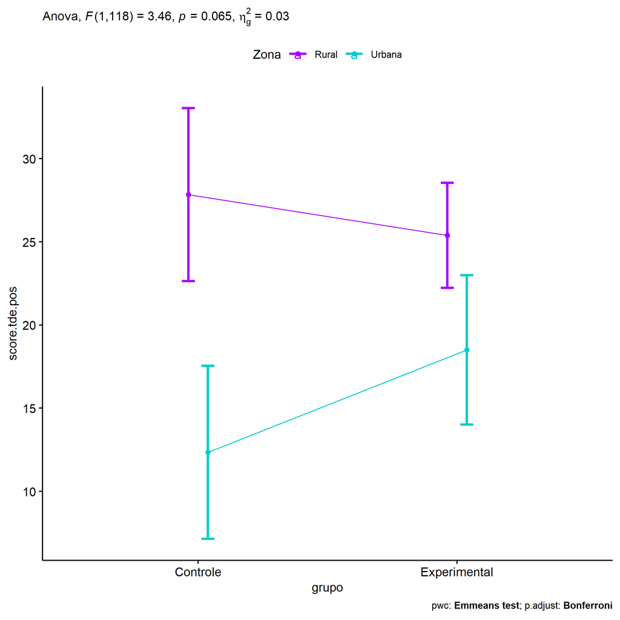

```r
if (!is.null(plots[["grupo"]]))
  plots[["grupo"]] + ggplot2::scale_color_manual(values = color[["Zona"]])
```

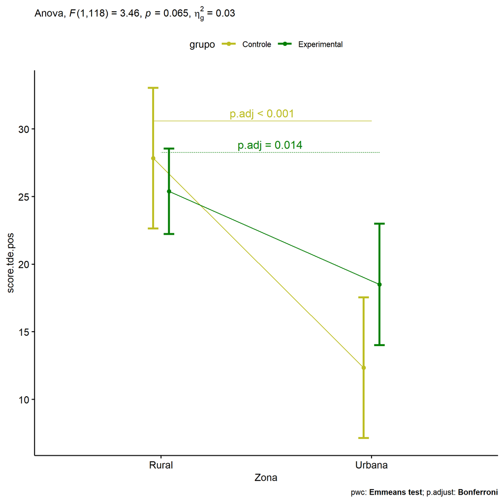

```r
if (!is.null(plots[["Zona"]]))
  plots[["Zona"]] + ggplot2::scale_color_manual(values = color[["grupo"]])
```

```r
plots <- twoWayAncovaBoxPlots(
  wdat, "score.tde.pos", c("grupo","Zona"), aov, pwcs, covar = "score.tde.pre",
  theme = "classic", color = color[["grupo:Zona"]],
  subtitle = which(aov$Effect == "grupo:Zona"))
```

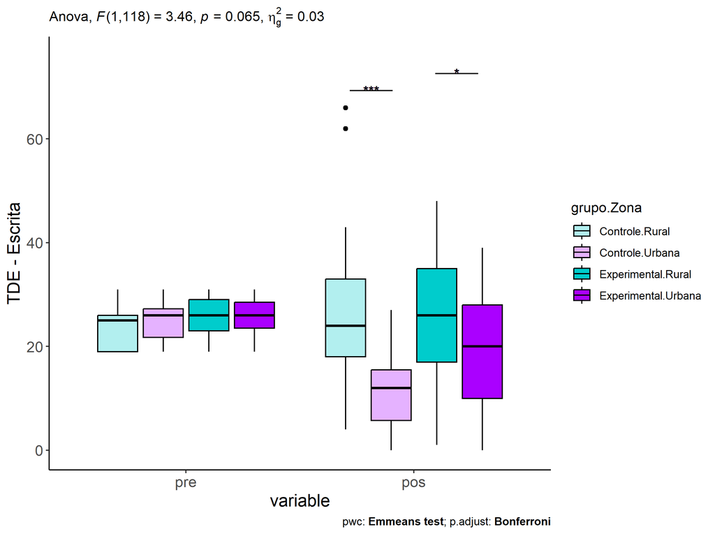

```r
plots[["grupo:Zona"]] + ggplot2::ylab("TDE - Escrita") + ggplot2::scale_x_discrete(labels=c('pre', 'pos'))
```

```r
plots <- twoWayAncovaBoxPlots(
  wdat.long, "score.tde", c("grupo","Zona"), aov, pwc.long, pre.post = "time",
  theme = "classic", color = color$prepost)
```

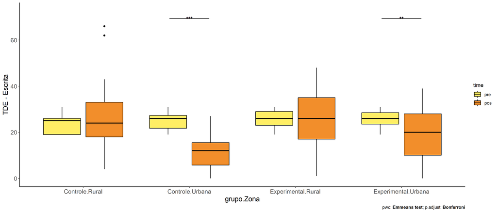

```r
plots[["grupo:Zona"]] + ggplot2::ylab("TDE - Escrita")
```

### Checking linearity assumption

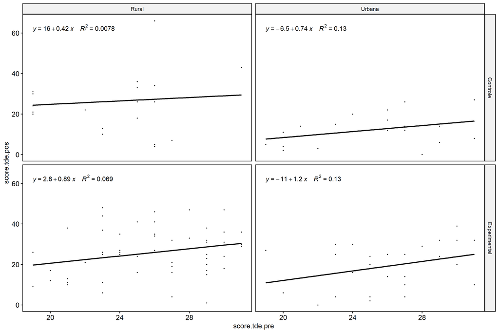

```r
ggscatter(wdat, x = "score.tde.pre", y = "score.tde.pos", size = 0.5,
          facet.by = c("grupo","Zona"), add = "reg.line")+
  stat_regline_equation(
    aes(label =  paste(..eq.label.., ..rr.label.., sep = "~~~~"))
  )
```

### Checking normality and homogeneity

```r
res <- augment(lm(score.tde.pos ~ score.tde.pre + grupo*Zona, data = wdat))
```

```r
shapiro_test(res$.resid)
```

```
## # A tibble: 1 × 3
##   variable   statistic p.value
##   <chr>          <dbl>   <dbl>
## 1 res$.resid     0.985   0.200
```

```r
levene_test(res, .resid ~ grupo*Zona)
```

```
## # A tibble: 1 × 4
##     df1   df2 statistic      p
##   <int> <int>     <dbl>  <dbl>
## 1     3   119      2.20 0.0922
```

# ANCOVA and Pairwise for two factors **grupo:Cor.Raca**

## Without remove non-normal data

```r
pdat = remove_group_data(dat[!is.na(dat[["grupo"]]) & !is.na(dat[["Cor.Raca"]]),], "score.tde.pos", c("grupo","Cor.Raca"))
pdat.long <- rbind(pdat[,c("id","grupo","Cor.Raca")], pdat[,c("id","grupo","Cor.Raca")])
pdat.long[["time"]] <- c(rep("pre", nrow(pdat)), rep("pos", nrow(pdat)))
pdat.long[["time"]] <- factor(pdat.long[["time"]], c("pre","pos"))
pdat.long[["score.tde"]] <- c(pdat[["score.tde.pre"]], pdat[["score.tde.pos"]])

aov = anova_test(pdat, score.tde.pos ~ score.tde.pre + grupo*Cor.Raca)
laov[["grupo:Cor.Raca"]] <- get_anova_table(aov)
```

```r
pwcs <- list()
pwcs[["Cor.Raca"]] <- emmeans_test(
  group_by(pdat, grupo), score.tde.pos ~ Cor.Raca,
  covariate = score.tde.pre, p.adjust.method = "bonferroni")
pwcs[["grupo"]] <- emmeans_test(
  group_by(pdat, Cor.Raca), score.tde.pos ~ grupo,
  covariate = score.tde.pre, p.adjust.method = "bonferroni")

pwc <- plyr::rbind.fill(pwcs[["grupo"]], pwcs[["Cor.Raca"]])
pwc <- pwc[,c("grupo","Cor.Raca", colnames(pwc)[!colnames(pwc) %in% c("grupo","Cor.Raca")])]
```

```r
pwc.long <- emmeans_test(dplyr::group_by_at(pdat.long, c("grupo","Cor.Raca")),
                         score.tde ~ time,
                         p.adjust.method = "bonferroni")
lpwc[["grupo:Cor.Raca"]] <- plyr::rbind.fill(pwc, pwc.long)
```

```r
ds <- get.descriptives(pdat, "score.tde.pos", c("grupo","Cor.Raca"), covar = "score.tde.pre")
ds <- merge(ds[ds$variable != "score.tde.pre",],
            ds[ds$variable == "score.tde.pre", !colnames(ds) %in% c("variable")],
            by = c("grupo","Cor.Raca"), all.x = T, suffixes = c("", ".score.tde.pre"))
ds <- merge(get_emmeans(pwcs[["grupo"]]), ds, by = c("grupo","Cor.Raca"), suffixes = c(".emms", ""))
ds <- ds[,c("grupo","Cor.Raca","n","mean.score.tde.pre","se.score.tde.pre","mean","se","emmean","se.emms")]

colnames(ds) <- c("grupo","Cor.Raca", "N", paste0(c("M","SE")," (pre)"),
                  paste0(c("M","SE"), " (unadj)"), paste0(c("M", "SE"), " (adj)"))

lemms[["grupo:Cor.Raca"]] <- ds
```

## Computing ANCOVA and PairWise After removing non-normal data (OK)

```r
wdat = pdat

res = residuals(lm(score.tde.pos ~ score.tde.pre + grupo*Cor.Raca, data = wdat))
non.normal = getNonNormal(res, wdat$id, plimit = 0.05)

wdat = wdat[!wdat$id %in% non.normal,]

wdat.long <- rbind(wdat[,c("id","grupo","Cor.Raca")], wdat[,c("id","grupo","Cor.Raca")])
wdat.long[["time"]] <- c(rep("pre", nrow(wdat)), rep("pos", nrow(wdat)))
wdat.long[["time"]] <- factor(wdat.long[["time"]], c("pre","pos"))
wdat.long[["score.tde"]] <- c(wdat[["score.tde.pre"]], wdat[["score.tde.pos"]])


ldat[["grupo:Cor.Raca"]] = wdat

(non.normal)
```

[output not shown]

```r
aov = anova_test(wdat, score.tde.pos ~ score.tde.pre + grupo*Cor.Raca)
laov[["grupo:Cor.Raca"]] <- merge(get_anova_table(aov), laov[["grupo:Cor.Raca"]], by="Effect", suffixes = c("","'"))

(df = get_anova_table(aov))
```

```
## ANOVA Table (type II tests)
##
##           Effect DFn DFd     F     p p<.05   ges
## 1  score.tde.pre   1  68 5.107 0.027     * 0.070
## 2          grupo   1  68 5.902 0.018     * 0.080
## 3       Cor.Raca   1  68 2.561 0.114       0.036
## 4 grupo:Cor.Raca   0  68    NA    NA  <NA>    NA
```

| Effect | DFn | DFd | F | p | p<.05 | ges |
| --- | --- | --- | --- | --- | --- | --- |
| score.tde.pre | 1 | 68 | 5.107 | 0.027 | * | 0.070 |
| grupo | 1 | 68 | 5.902 | 0.018 | * | 0.080 |
| Cor.Raca | 1 | 68 | 2.561 | 0.114 |  | 0.036 |
| grupo:Cor.Raca | 0 | 68 |  |  |  |  |

```r
pwcs <- list()
pwcs[["Cor.Raca"]] <- emmeans_test(
  group_by(wdat, grupo), score.tde.pos ~ Cor.Raca,
  covariate = score.tde.pre, p.adjust.method = "bonferroni")
pwcs[["grupo"]] <- emmeans_test(
  group_by(wdat, Cor.Raca), score.tde.pos ~ grupo,
  covariate = score.tde.pre, p.adjust.method = "bonferroni")

pwc <- plyr::rbind.fill(pwcs[["grupo"]], pwcs[["Cor.Raca"]])
pwc <- pwc[,c("grupo","Cor.Raca", colnames(pwc)[!colnames(pwc) %in% c("grupo","Cor.Raca")])]
```

| grupo | Cor.Raca | term | .y. | group1 | group2 | df | statistic | p | p.adj | p.adj.signif |
| --- | --- | --- | --- | --- | --- | --- | --- | --- | --- | --- |
|  | Branca | score.tde.pre*grupo | score.tde.pos | Controle | Experimental |  |  |  |  |  |
|  | Parda | score.tde.pre*grupo | score.tde.pos | Controle | Experimental | 68 | -2.429 | 0.018 | 0.018 | * |
| Controle |  | score.tde.pre*Cor.Raca | score.tde.pos | Branca | Parda |  |  |  |  |  |
| Experimental |  | score.tde.pre*Cor.Raca | score.tde.pos | Branca | Parda | 68 | -1.600 | 0.114 | 0.114 | ns |

```r
pwc.long <- emmeans_test(dplyr::group_by_at(wdat.long, c("grupo","Cor.Raca")),
                         score.tde ~ time,
                         p.adjust.method = "bonferroni")
lpwc[["grupo:Cor.Raca"]] <- merge(plyr::rbind.fill(pwc, pwc.long), lpwc[["grupo:Cor.Raca"]], by=c("grupo","Cor.Raca","term",".y.","group1","group2"), suffixes = c("","'"))
```

| grupo | Cor.Raca | term | .y. | group1 | group2 | df | statistic | p | p.adj | p.adj.signif |
| --- | --- | --- | --- | --- | --- | --- | --- | --- | --- | --- |
| Controle | Branca | time | score.tde | pre | pos |  |  |  |  |  |
| Controle | Parda | time | score.tde | pre | pos | 138 | 2.572 | 0.011 | 0.011 | * |
| Experimental | Branca | time | score.tde | pre | pos | 138 | 1.600 | 0.112 | 0.112 | ns |
| Experimental | Parda | time | score.tde | pre | pos | 138 | -0.171 | 0.864 | 0.864 | ns |

```r
ds <- get.descriptives(wdat, "score.tde.pos", c("grupo","Cor.Raca"), covar = "score.tde.pre")
ds <- merge(ds[ds$variable != "score.tde.pre",],
            ds[ds$variable == "score.tde.pre", !colnames(ds) %in% c("variable")],
            by = c("grupo","Cor.Raca"), all.x = T, suffixes = c("", ".score.tde.pre"))
ds <- merge(get_emmeans(pwcs[["grupo"]]), ds, by = c("grupo","Cor.Raca"), suffixes = c(".emms", ""))
ds <- ds[,c("grupo","Cor.Raca","n","mean.score.tde.pre","se.score.tde.pre","mean","se","emmean","se.emms")]

colnames(ds) <- c("grupo","Cor.Raca", "N", paste0(c("M","SE")," (pre)"),
                  paste0(c("M","SE"), " (unadj)"), paste0(c("M", "SE"), " (adj)"))

lemms[["grupo:Cor.Raca"]] <- merge(ds, lemms[["grupo:Cor.Raca"]], by=c("grupo","Cor.Raca"), suffixes = c("","'"))
```

| grupo | Cor.Raca | N | M (pre) | SE (pre) | M (unadj) | SE (unadj) | M (adj) | SE (adj) |
| --- | --- | --- | --- | --- | --- | --- | --- | --- |
| Controle | Parda | 17 | 25.765 | 0.842 | 17.706 | 2.627 | 17.541 | 2.941 |
| Experimental | Branca | 9 | 27.111 | 0.716 | 20.222 | 3.996 | 18.728 | 4.095 |
| Experimental | Parda | 46 | 25.239 | 0.511 | 25.565 | 1.931 | 25.919 | 1.794 |